# STAT 331 Portfolio

Author

Jonathan Zhao

**My Grade:** I believe my grade equivalent to course work evidenced below to be an B.

**Learning Objective Evidence:** In the code chunks below, provide code from Lab or Challenge assignments where you believe you have demonstrated proficiency with the specified learning target. Be sure to specify **where** the code came from (e.g., Lab 4 Question 2).

## Working with Data

**WD-1: I can import data from a *variety* of formats (e.g., csv, xlsx, txt, etc.).**

- `csv`

```r
teacher_evals_compare <- read_csv(here("data", "teacher_evals.csv"))

#Challenge 3 Question 1
```

- `xlsx`

```r
military <- read_xlsx(here::here("data",
                                 "gov_spending_per_capita.xlsx"),
                      sheet = "Share of Govt. spending",
                      skip  = 7,
                      n_max = 190,
                      na = c(". .", "xxx" )
                      )
#Practice Activity 4 Question 3
```

- `txt`

```r
ages_mystery <- read_delim(file = here::here("Week 2",
                                             "Check-ins",
                                             "Ages_Data",
                                             "ages_mystery.txt"),
                           delim = "|")

#Week 2 Check In
```

**WD-2: I can select necessary columns from a dataset.**

```r
get_fit_now_member |>
  filter(membership_status == 'gold', str_detect(id, "^48Z")) |>
  left_join(get_fit_now_check_in, join_by(id == membership_id)) |>
  filter(year(as.Date(as.character(check_in_date), format = "%Y%m%d")) == 2018,
         month(as.Date(as.character(check_in_date), format = "%Y%m%d")) == 1,
         day(as.Date(as.character(check_in_date), format = "%Y%m%d")) == 9) |>
  left_join(person, join_by(person_id == id)) |>
  right_join(drivers_license, join_by(license_id == id)) |>
  filter(!is.na(id)) |>
  filter(str_detect(plate_number, "H42W")) |>
  select(id, name.x, plate_number, gender)

#Lab 5
#Added right_join()
```

**WD-3: I can filter rows from a dataframe for a *variety* of data types (e.g., numeric, integer, character, factor, date).**

- numeric

```r
table <- ca_childcare |>
  filter(study_year %in% c(2008,2018)) |>
  group_by(region, study_year) |>
  summarise(median_income = median(mhi_2018)) |>
  pivot_wider(names_from = study_year, values_from = median_income) |>
  rename("Year2008" = `2008`,
         "Year2018" = `2018`) |>
  arrange(desc(`2018`))

#Lab 4 Question 4
#Revision: Changing the name of the variables, because the name of 2008 or 2018 is very confusing to someone who did not work with the code
```

- character – specifically a string (example must use functions from **stringr**)

```r
person |>
  filter(
    (address_street_name %in% "Northwestern Dr" &
     address_number == max(address_number[address_street_name == "Northwestern Dr"])) |
    (address_street_name %in% "Franklin Ave" &
     str_detect(name, "^Annabel"))) |>
  rename(person_id = id) |>
  inner_join(interview, by = "person_id") |>
  select(transcript)

#Lab 5
```

- factor

```r
facebook_event_checkin |>
  mutate(date = ymd(date)) |>
  filter(event_name == "SQL Symphony Concert",
         year(date) == 2017,
         month(date) == 12) |>
  count(person_id) |>
  filter(n == 3) |>
  left_join(person, join_by(person_id == id)) |>
  left_join(drivers_license, join_by(license_id == id)) |>
  mutate(hair_color = as.factor(hair_color),
         gender = as.factor(gender),
         car_make = as.factor(car_make),
         car_model = as.factor(car_model)) |>
  filter(height >= 65 & height <= 67,
         hair_color == "red",
         gender == "female",
         car_make == "Tesla",
         car_model == "Model S") |>
  anti_join(interview, join_by(person_id == person_id))

#Lab 5
#Revision: Finished the Lab, as I did not check the interview of Jeremey Bowers. I then used the clues from his interview to check with someone that did not have an interview to find the mastermind behind the murder
```

- date (example must use functions from **lubridate**)

```r
facebook_event_checkin |>
  mutate(date = ymd(date)) |>
  filter(event_name == "SQL Symphony Concert",
         year(date) == 2017,
         month(date) == 12) |>
  count(person_id) |>
  filter(n == 3) |>
  left_join(person, join_by(person_id == id)) |>
  left_join(drivers_license, join_by(license_id == id)) |>
  mutate(hair_color = as.factor(hair_color),
         gender = as.factor(gender),
         car_make = as.factor(car_make),
         car_model = as.factor(car_model)) |>
  filter(height >= 65 & height <= 67,
         hair_color == "red",
         gender == "female",
         car_make == "Tesla",
         car_model == "Model S") |>
  anti_join(interview, join_by(person_id == person_id))

#Lab 5
#Revision: Finished the Lab, as I did not check the interview of Jeremey Bowers. I then used the clues from his interview to check with someone that did not have an interview to find the mastermind behind the murder
```

**WD-4: I can modify existing variables and create new variables in a dataframe for a *variety* of data types (e.g., numeric, integer, character, factor, date).**

- numeric (using `as.numeric()` is not sufficient)

```r
teacher_evals_compare <- read_csv(here("data", "teacher_evals.csv")) |>
  mutate(SET_level = if_else(
          SET_score_avg >= 4, "excellent", "standard"),
        sen_level = if_else(
          seniority <= 4, "junior", "senior")) |>
  select(course_id, SET_level, sen_level)

#Challenge 3 Lab 1
```

- character – specifically a string (example must use functions from **stringr**)

```r
babyResults |>
  count(ncorrect) |>
  mutate(Proportion = n / sum(n),
         ncorrect_label = str_c("Correct: ", ncorrect)) |>
  select(ncorrect_label, Proportion) |>
  rename(`Correctly Returned Babies` = ncorrect_label) |>

  gt() |>
  tab_header(title = "Percentage of Correctly Returned Babies",
             subtitle = "Simulation Results") |>
  cols_align(align = "left",
             columns = everything()) |>
  fmt_percent(columns = Proportion,
              decimals = 2) |>
  cols_label(Proportion = "Percentage") |>
  opt_row_striping() |>
  opt_table_font(font = "Comic Sans MS")

#Lab 9 Q2
#Revisions: Added str_c to utlize stringr
```

- factor (example must use functions from **forcats**)

```r
mutate(region = fct_collapse(county_name,
                              "Superior California" = c("Butte County", "Colusa County", "Del Norte County",
                                                        "Glenn County", "Humboldt County", "Lassen County",
                                                        "Modoc County", "Plumas County", "Shasta County",
                                                        "Sierra County", "Siskiyou County", "Tehama County",
                                                        "Trinity County"),
                              "San Francisco Bay Area" = c("Alameda County", "Contra Costa County", "Marin County",
                                                           "Napa County", "San Francisco County", "San Mateo County",
                                                           "Santa Clara County", "Solano County", "Sonoma County"),
                              "Northern San Joaquin Valley" = c("San Joaquin County", "Stanislaus County", "Merced County"),
                              "Sacramento Area" = c("El Dorado County", "Placer County", "Sacramento County",
                                                    "Sutter County", "Yolo County", "Yuba County"),
                              "Central Coast" = c("Monterey County", "San Benito County", "San Luis Obispo County",
                                                  "Santa Barbara County", "Santa Cruz County", "Ventura County"),
                              "Northern California & Central Sierra" = c("Alpine County", "Amador County",
                                                                          "Calaveras County", "Inyo County", "Mariposa County",
                                                                          "Mono County", "Nevada County", "Tuolumne County"),
                               "Southern California" = c("Los Angeles County", "Orange County", "Riverside County",
                                                         "San Bernardino County", "San Diego County", "Imperial County"),
                               "Central Valley" = c("Fresno County", "Kern County", "Kings County", "Madera County", "Tulare County"),
                               "Inland Empire" = c("Riverside County", "San Bernardino County"),
                               "San Diego Area" = c("San Diego County", "Imperial County")))

#Lab 4 Question 3
```

- date (example must use functions from **lubridate**)

```r
get_fit_now_member |>
  filter(membership_status == 'gold', str_detect(id, "^48Z")) |>
  left_join(get_fit_now_check_in, join_by(id == membership_id)) |>
  filter(year(as.Date(as.character(check_in_date), format = "%Y%m%d")) == 2018,
         month(as.Date(as.character(check_in_date), format = "%Y%m%d")) == 1,
         day(as.Date(as.character(check_in_date), format = "%Y%m%d")) == 9) |>
  left_join(person, join_by(person_id == id)) |>
  right_join(drivers_license, join_by(license_id == id)) |>
  filter(!is.na(id)) |>
  filter(str_detect(plate_number, "H42W")) |>
  select(id, name.x, plate_number, gender)

#Lab 5
#Revision: The original read the date as an integer, but this was changed in order to utilize lubridate
#Added right_join()
```

**WD-5: I can use mutating joins to combine multiple dataframes.**

- `left_join()`

```r
ca_childcare <- counties |>
  filter(state_name %in% "California") |>
  left_join(childcare_costs, by = "county_fips_code")

#Lab 4 Question 2
```

- `right_join()`

```r
get_fit_now_member |>
  filter(membership_status == 'gold', str_detect(id, "^48Z")) |>
  left_join(get_fit_now_check_in, join_by(id == membership_id)) |>
  filter(year(as.Date(as.character(check_in_date), format = "%Y%m%d")) == 2018,
         month(as.Date(as.character(check_in_date), format = "%Y%m%d")) == 1,
         day(as.Date(as.character(check_in_date), format = "%Y%m%d")) == 9) |>
  left_join(person, join_by(person_id == id)) |>
  right_join(drivers_license, join_by(license_id == id)) |>
  filter(!is.na(id)) |>
  filter(str_detect(plate_number, "H42W")) |>
  select(id, name.x, plate_number, gender)

#Lab 5
#Added right_join()
```

- `inner_join()`

```r
person |>
  filter(
    (address_street_name %in% "Northwestern Dr" &
     address_number == max(address_number[address_street_name == "Northwestern Dr"])) |
    (address_street_name %in% "Franklin Ave" &
     str_detect(name, "^Annabel")))|>
    inner_join(interview, by = c("id" = "person_id")) |>
  select(transcript)

#Lab 5
#Revision: Finished the Lab, as I did not check the interview of Jeremey Bowers. I then used the clues from his interview to check with someone that did not have an interview to find the mastermind behind the murder
```

**WD-6: I can use filtering joins to filter rows from a dataframe.**

- `semi_join()`

```r
interview |>
      semi_join(suspects, join_by(person_id == person_id)) |>
      select(transcript)

#Lab 5
#Revision: Finished the Lab, as I did not check the interview of Jeremey Bowers. I then used the clues from his interview to check with someone that did not have an interview to find the mastermind behind the murder
```

- `anti_join()`

```r
facebook_event_checkin |>
  mutate(date = ymd(date)) |>
  filter(event_name == "SQL Symphony Concert",
         year(date) == 2017,
         month(date) == 12) |>
  count(person_id) |>
  filter(n == 3) |>
  left_join(person, join_by(person_id == id)) |>
  left_join(drivers_license, join_by(license_id == id)) |>
  filter(height >= 65 & height <= 67,
         hair_color == "red",
         gender == "female",
         car_make == "Tesla",
         car_model == "Model S") |>
  anti_join(interview, join_by(person_id == person_id))

#Lab 5
#Revision: Finished the Lab, as I did not check the interview of Jeremey Bowers. I then used the clues from his interview to check with someone that did not have an interview to find the mastermind behind the murder
```

**WD-7: I can pivot dataframes from long to wide and visa versa**

- `pivot_longer()`

```r
ca_childcare |>

  rename(Infant = mc_infant,
         Toddler = mc_toddler,
         Preschool = mc_preschool) |>

  pivot_longer(cols = c(Infant, Toddler, Preschool),
               names_to = "age_group",
               values_to = "median_weekly_price") |>

  ggplot(mapping = aes(x = study_year,
                      y = median_weekly_price,
                      color = region)) +
  geom_point(alpha = 0.3) +
  geom_smooth() +
  facet_grid(.~age_group) +
  labs(x = "Year",
       y = "",
       subtitle = "Weekly Median Price for Center-Based Childcare ($)",
       color = "Region") +
  scale_x_continuous(breaks = seq(2008, 2018, by = 2)) +
  scale_y_continuous(breaks = seq(100, 500, by = 100)) +
  theme_light() +
  theme(aspect.ratio = 1, axis.text.x = element_text(size = 6),
        legend.text = element_text(size = 8))

#Lab 4 Question 6
```

- `pivot_wider()`

```r
table <- ca_childcare |>
  filter(study_year %in% c(2008,2018)) |>
  group_by(region, study_year) |>
  summarise(median_income = median(mhi_2018)) |>
  pivot_wider(names_from = study_year, values_from = median_income) |>
  rename("Year 2008" = `2008`,
         "Year 2018" = `2018`) |>
  arrange(desc(`2018`))

#Lab 4 Question 4
#Revision: Changing the name of the variables, because the name of 2008 or 2018 is very confusing to someone who did not work with the code
```

## Reproducibility

**R-1: I can create professional looking, reproducible analyses using RStudio projects, Quarto documents, and the here package.**

I’ve done this in the following provided assignments:

Labs 1 - 9, Challenges 1 - 9

**R-2: I can write well documented and tidy code.**

- Example of **ggplot2** plotting

```r
ca_childcare |>

  rename(Infant = mc_infant,
         Toddler = mc_toddler,
         Preschool = mc_preschool) |>

  pivot_longer(cols = c(Infant, Toddler, Preschool),
               names_to = "age_group",
               values_to = "median_weekly_price") |>

  ggplot(mapping = aes(x = study_year,
                      y = median_weekly_price,
                      color = region)) +
  geom_point(alpha = 0.3) +
  geom_smooth() +
  facet_grid(.~age_group) +
  labs(x = "Year",
       y = "",
       subtitle = "Weekly Median Price for Center-Based Childcare ($)",
       color = "Region") +
  scale_x_continuous(breaks = seq(2008, 2018, by = 2)) +
  scale_y_continuous(breaks = seq(100, 500, by = 100)) +
  theme_light() +
  theme(aspect.ratio = 1, axis.text.x = element_text(size = 6),
        legend.text = element_text(size = 8))

#Lab 4 Question 6
```

- Example of **dplyr** pipeline

```r
table <- ca_childcare |>
  filter(study_year %in% c(2008,2018)) |>
  group_by(region, study_year) |>
  summarise(median_income = median(mhi_2018)) |>
  pivot_wider(names_from = study_year, values_from = median_income) |>
  rename("Year2008" = `2008`,
         "Year2018" = `2018`) |>
  arrange(desc(`2018`))

#Lab 4 Question 4
#Revision: Changing the name of the variables, because the name of 2008 or 2018 is very confusing to someone who did not work with the code
```

- Example of function formatting

```r
randomBabies <- function(nBabies){
  trueOrder <- 1:nBabies
  shuffledOrder <- sample(trueOrder) #I learned this in 305
  return(sum(shuffledOrder == trueOrder))
}

results <- map_int(.x = 1:10000,
                   .f = ~randomBabies(nBabies = 5)
                   )

#Lab 9 Q1
```

**R-3: I can write robust programs that are resistant to changes in inputs.**

- Example – any context

```r
ca_childcare |>
  group_by(region) |>
  summarize(mfcc_infant = median(mfcc_infant)) |>
  rename(Median_Income = mfcc_infant) |>
  arrange(Median_Income) |>
  slice(1)

#Lab 4 Q5
```

- Example of function stops

```r
conditionIndex <- function(length, weight) {
  stopifnot(is.vector(length), is.vector(weight))

  return((weight / (length^3)) * 100)
}

#Challenge 7 Q3
```

## Data Visualization & Summarization

**DVS-1: I can create visualizations for a *variety* of variable types (e.g., numeric, character, factor, date)**

- at least two numeric variables

```r
ggplot(data = surveys,
       mapping = aes(
         x = weight,
         y = hindfoot_length,
         alpha = 0.1)
       ) +
  geom_point() +
  facet_wrap(.~species)+
  labs(x = "Weight (g)", y = "", subtitle = "Hindfoot Length (mm)")

#Lab 2 Question 4
```

- at least one numeric variable and one categorical variable

```r
ggplot(data = ToothGrowth,
       mapping = aes(x = supp, y = len)) +
  geom_boxplot() +
  labs(x = "Supplement", y = "Length of Teeth (mm)")

#Lab 1 Question 6
```

- at least two categorical variables

```r
teacher_evals_clean |>
  ggplot(aes(x = seniority, fill = sex)) +
    geom_bar() +
  facet_grid( ~ academic_degree)

#Lab 3 Q7
```

- dates (timeseries plot)

```r
ggplot(fish, aes(x = year, y = conditionIndex(length, weight))) +
  geom_jitter(alpha = 0.6) +
  geom_smooth(method = "lm", se = FALSE) +
  facet_wrap(~ species, scales = "free_y") +
  labs(title = "Variation in Fish Condition Index Over Time by Species",
      x = "Year",
      y = "",
      subtitle = "Condition Index",
    color = "Species")

#Lab 4 Question 6
```

**DVS-2: I use plot modifications to make my visualization clear to the reader.**

- I can ensure people don’t tilt their head

```r
ggplot(data = surveys,
       mapping = aes(
         x = weight,
         y = hindfoot_length,
         alpha = 0.1)
       ) +
  geom_point() +
  facet_wrap(.~species)+
  labs(x = "Weight (g)", y = "", subtitle = "Hindfoot Length (mm)")

#Lab 7 Question 4
```

- I can modify the text in my plot to be more readable

```r
ca_childcare |>

  rename(Infant = mc_infant,
         Toddler = mc_toddler,
         Preschool = mc_preschool) |>

  pivot_longer(cols = c(Infant, Toddler, Preschool),
               names_to = "age_group",
               values_to = "median_weekly_price") |>

  mutate(age_group = fct_reorder2(age_group, study_year, median_weekly_price)) |>

  ggplot(mapping = aes(x = study_year,
                      y = median_weekly_price,
                      color = region)) +
  geom_point(alpha = 0.3) +
  geom_smooth() +
  facet_grid(.~age_group) +
  labs(x = "Year",
       y = "",
       subtitle = "Weekly Median Price for Center-Based Childcare ($)",
       color = "Region") +
  scale_x_continuous(breaks = seq(2008, 2018, by = 2)) +
  scale_y_continuous(breaks = seq(100, 500, by = 100)) +
  theme_bw() +
  theme(aspect.ratio = 1, axis.text.x = element_text(size = 6),
        legend.text = element_text(size = 8),
        legend.key.size = unit(0.4, "cm"))

#Lab 4 Q6
```

- I can reorder my legend to align with the colors in my plot

```r
ca_childcare |>

  rename(Infant = mc_infant,
         Toddler = mc_toddler,
         Preschool = mc_preschool) |>

  pivot_longer(cols = c(Infant, Toddler, Preschool),
               names_to = "age_group",
               values_to = "median_weekly_price") |>

  mutate(age_group = fct_reorder2(age_group, study_year, median_weekly_price)) |>

  ggplot(mapping = aes(x = study_year,
                      y = median_weekly_price,
                      color = region)) +
  geom_point(alpha = 0.3) +
  geom_smooth() +
  facet_grid(.~age_group) +
  labs(x = "Year",
       y = "",
       subtitle = "Weekly Median Price for Center-Based Childcare ($)",
       color = "Region") +
  scale_x_continuous(breaks = seq(2008, 2018, by = 2)) +
  scale_y_continuous(breaks = seq(100, 500, by = 100)) +
  theme_bw() +
  theme(aspect.ratio = 1, axis.text.x = element_text(size = 6),
        legend.text = element_text(size = 8),
        legend.key.size = unit(0.4, "cm"))

#Lab 4 Q6
```

**DVS-3: I show creativity in my visualizations**

- I can use non-standard colors

```r
ggplot(data = surveys,
       mapping = aes(
         x = species,
         y = weight,
         color = genus)
       ) +
  geom_boxplot(outliers = FALSE) +
  geom_jitter(alpha = 0.1, aes(color = genus)) +
  scale_color_brewer(palette = "Set2") +
  labs(x = "Species", y = "", subtitle = "Weight (g)")

#Challenge 2 Difficulty 2
```

- I can use annotations

```r
ggplot(data = surveys,
       mapping = aes(y = species,
                     x = weight,
                     color = genus)) +
  geom_boxplot() +
  scale_color_brewer(palette = "Set2") +
  annotate("text", y = 14, x = 250, label = "Onychomys") +
  annotate("text", y = 13, x = 250, label = "Dipodomys") +
  annotate("text", y = 12, x = 250, label = "Chaetodipus") +
  annotate("text", y = 11, x = 250, label = "Dipodomys") +
  annotate("text", y = 10, x = 250, label = "Dipodomys") +
  annotate("text", y = 9, x = 250, label = "Reithrodontomys") +
  annotate("text", y = 8, x = 250, label = "Peromyscus") +
  annotate("text", y = 7, x = 250, label = "Onychomys") +
  annotate("text", y = 6, x = 250, label = "Sigmodon") +
  annotate("text", y = 5, x = 250, label = "Reithrodontomys") +
  annotate("text", y = 4, x = 250, label = "Perognathus") +
  annotate("text", y = 3, x = 250, label = "Peromyscus") +
  annotate("text", y = 2, x = 250, label = "Chaetodipus") +
  annotate("text", y = 1, x = 250, label = "Neotoma") +

  theme(legend.position = "none") +
  labs(x = "Weight (g)",
       y = "",
       subtitle = "Species",
       title = "Rodent Weight by Species")
  annotate("text", y = 13, x = 250, label = "Dipodomys")

#Challenge 2 Difficulty 3
```

- I can be creative…

```r
ggplot(data = surveys,
       mapping = aes(
         x = species,
         y = weight,
         color = genus)
       ) +
  geom_boxplot(outliers = FALSE) +
  geom_jitter(alpha = 0.1, aes(color = genus)) +
  scale_color_brewer(palette = "Set2") +
  labs(x = "Species", y = "", subtitle = "Weight (g)")

#Challenge 2 Difficulty 2
```

**DVS-4: I can calculate numerical summaries of variables.**

- Example using `summarize()`

```r
teacher_evals_clean |>
  filter(seniority >= 1) |>
  group_by(teacher_id) |>
  summarize(avgFail = mean(percent_failed_cur, na.rm = TRUE)) |>
  filter(avgFail == min(avgFail) | avgFail == max(avgFail)) |>
  arrange(avgFail)

#Lab 3 Question 11
```

- Example using `across()`

```r
fish |>
  summarise(across(everything(), ~ sum(is.na(.)))) |>
  pivot_longer(cols = everything(), names_to = "Variable", values_to = "Number of Missing Values") |>
  gt() |>
  tab_header(
    title = "Missing Values in fish Dataset")

#Lab 8 Q4
```

**DVS-5: I can find summaries of variables across multiple groups.**

- Example 1

```r
table <- ca_childcare |>
  filter(study_year %in% c(2008,2018)) |>
  group_by(region, study_year) |>
  summarise(median_income = median(mhi_2018)) |>
  pivot_wider(names_from = study_year, values_from = median_income) |>
  arrange(desc(`2018`))

#Lab 4 Question 4
```

- Example 2

```r
  summarize(uniqueCourses = n_distinct(course_id),
            uniqueInstructors = n_distinct(teacher_id))

#Lab 3 Question 6
```

**DVS-6: I can create tables which make my summaries clear to the reader.**

- Example 1

```r
all_simulations |>
  group_by(n) |>
  summarize("Mean of Simulated Means" = mean(simulated_means)) |>

kable(caption = "Simulated Means",
      col.names = c("Number of Simulations", "Mean of Simulated Means"),
      digits = 3, align = "l")

#Lab 9 Q7
```

- Example 2

```r
babyResults |>
  count(ncorrect) |>
  mutate(Proportion = n / sum(n),
         ncorrect_label = str_c("Correct: ", ncorrect)) |>
  select(ncorrect_label, Proportion) |>
  rename(`Correctly Returned Babies` = ncorrect_label) |>

  gt() |>
  tab_header(title = "Percentage of Correctly Returned Babies",
             subtitle = "Simulation Results") |>
  cols_align(align = "left",
             columns = everything()) |>
  fmt_percent(columns = Proportion,
              decimals = 2) |>
  cols_label(Proportion = "Percentage") |>
  opt_row_striping() |>
  opt_table_font(font = "Comic Sans MS")

#Lab 9 Q2
#Revisions: Added more personalization to gt table, as wella s utilizing stringr
```

**DVS-7: I show creativity in my tables.**

- Example 1

```r
babyResults |>
  count(ncorrect) |>
  mutate(Proportion = n / sum(n),
         ncorrect_label = str_c("Correct: ", ncorrect)) |>
  select(ncorrect_label, Proportion) |>
  rename(`Correctly Returned Babies` = ncorrect_label) |>

  gt() |>
  tab_header(title = "Percentage of Correctly Returned Babies",
             subtitle = "Simulation Results") |>
  cols_align(align = "left",
             columns = everything()) |>
  fmt_percent(columns = Proportion,
              decimals = 2) |>
  cols_label(Proportion = "Percentage") |>
  opt_row_striping() |>
  opt_table_font(font = "Comic Sans MS")

#I thought it would be funny for comic sans

#Lab 9 Q2
```

- Example 2

```r
fish |>
  summarise(across(everything(), ~ sum(is.na(.)))) |>
  pivot_longer(cols = everything(),
               names_to = "Variable",
               values_to = "Number of Missing Values") |>
  gt() |>
  tab_header(
    title = "Missing Values in fish Dataset") |>
  tab_style(
    style = cell_fill(color = "#FFEC8F"),
    locations = cells_body(
      rows = Variable == "weight"
    )) |>
  opt_row_striping() |>
  opt_table_font(font = "Comfortaa")


#Lab 8 Q4, edited by Challenge 9
```

## Program Efficiency

**PE-1: I can write concise code which does not repeat itself.**

- using a single function call with multiple inputs (rather than multiple function calls)

```r
crime_scene_report |>
  filter(str_detect(date, "20180115"),
         str_detect(type, "murder"),
         str_detect(city, "SQL City")) |>
  select(description)

#Lab 5
```

- `across()`

```r
fish |>
  summarise(across(everything(), ~ sum(is.na(.)))) |>
  pivot_longer(cols = everything(), names_to = "Variable", values_to = "Number of Missing Values") |>
  gt() |>
  tab_header(
    title = "Missing Values in fish Dataset")

#Lab 8 Q4
```

- `map()` functions

```r
evals <- bind_cols(map_at(evals,
                 c("teacher_id",
                          "weekday",
                          "academic_degree",
                          "seniority",
                          "sex"),
                 as.factor))

#Lab 8 Q2
```

**PE-2: I can write functions to reduce repetition in my code.**

- Function that operates on vectors

```r
conditionIndex <- function(length, weight) {
  stopifnot(is.vector(length), is.vector(weight))

  return((weight / (length^3)) * 100)
}

#Challenge 7 Q3
```

- Function that operates on data frames

```r
simulate_means <- function(n, df){
  map_dbl(.x = 1:n,
          .f = ~rchisq(n = 100, df = df) %>% mean()
          )
}

#Lab 9 Q7
```

**PE-3:I can use iteration to reduce repetition in my code.**

- `across()`

```r
fish |>
  summarise(across(everything(), ~ sum(is.na(.)))) |>
  pivot_longer(cols = everything(), names_to = "Variable", values_to = "Number of Missing Values") |>
  gt() |>
  tab_header(
    title = "Missing Values in fish Dataset")

#Lab 8 Q4
```

- `map()` function with **one** input (e.g., `map()`, `map_chr()`, `map_dbl()`, etc.)

```r
fish|>
  map_int(~ sum(is.na(.)))

#Lab 8 Q4
```

- `map()` function with **more than one** input (e.g., `map_2()` or `pmap()`)

```r
all_simulations <- grid |>
  mutate(simulated_means = pmap(.l = list(n = n, df = df),
                                .f = simulate_means)
         ) |>
  unnest(simulated_means)

#Lab 9 Q6
```

**PE-4: I can use modern tools when carrying out my analysis.**

- I can use functions which are not superseded or deprecated

```r
get_fit_now_member |>
  filter(membership_status == 'gold', str_detect(id, "^48Z")) |>
  left_join(get_fit_now_check_in, join_by(id == membership_id)) |>
  filter(year(as.Date(as.character(check_in_date), format = "%Y%m%d")) == 2018,
         month(as.Date(as.character(check_in_date), format = "%Y%m%d")) == 1,
         day(as.Date(as.character(check_in_date), format = "%Y%m%d")) == 9) |>
  left_join(person, join_by(person_id == id)) |>
  right_join(drivers_license, join_by(license_id == id)) |>
  filter(!is.na(id)) |>
  filter(str_detect(plate_number, "H42W")) |>
  select(id, name.x, plate_number, gender)

#Lab 5
```

- I can connect a data wrangling pipeline into a `ggplot()`

```r
ca_childcare |>

  rename(Infant = mc_infant,
         Toddler = mc_toddler,
         Preschool = mc_preschool) |>

  pivot_longer(cols = c(Infant, Toddler, Preschool),
               names_to = "age_group",
               values_to = "median_weekly_price") |>

  ggplot(mapping = aes(x = study_year,
                      y = median_weekly_price,
                      color = region)) +
  geom_point(alpha = 0.3) +
  geom_smooth() +
  facet_grid(.~age_group) +
  labs(x = "Year",
       y = "",
       subtitle = "Weekly Median Price for Center-Based Childcare ($)",
       color = "Region") +
  scale_x_continuous(breaks = seq(2008, 2018, by = 2)) +
  scale_y_continuous(breaks = seq(100, 500, by = 100)) +
  theme_bw() +
  theme(aspect.ratio = 1, axis.text.x = element_text(size = 6),
        legend.text = element_text(size = 8))

#Lab 4 Question 6
```

## Data Simulation & Statistical Models

**DSSM-1: I can simulate data from a *variety* of probability models.**

- Example 1

```r
randomBabies <- function(nBabies){
  trueOrder <- 1:nBabies
  shuffledOrder <- sample(trueOrder) #I learned this in 305
  return(sum(shuffledOrder == trueOrder))
}

results <- map_int(.x = 1:10000,
                   .f = ~randomBabies(nBabies = 4)
                   )

#Lab 9 Q1
```

- Example 2

```r
simulate_means <- function(n, df){
  map_dbl(.x = 1:n,
          .f = ~rchisq(n = 100, df = df) %>% mean()
          )
}

#Lab 9 Q4
```

**DSSM-2: I can conduct common statistical analyses in R.**

- Example 1

```r
species_mod <- aov(weight~species, data = surveys)

summary(species_mod)

#Lab 2 Question 17
```

- Example 2

```r
chiSquaredTest <- chisq.test(teacher_evals_compare $ SET_level, teacher_evals_compare $ sen_level)

#Challenge 3 Q3
```

## Revising My Thinking

I revised the majority of my labs and challenges throughout this course. The vast majority of the code in the portfolio is post-revision, and typically is consisted of changing small mistakes that comes from misreading the problem, or an inefficiency or a bad way of conducting the cleaning of data. I think that my reflections are present, but do miss some of the bigger picture ideas. In some cases, such as in Lab 5, my original ideas were flawed, and I had to extensively redo my thinking in order to demonstrate my understanding, as shown in the above portfolio. I do make an attempt to fix errors in future assignments, such as including code wrapping in the yaml after the first couple labs.

## Extending My Thinking

I attempted the harder difficulty in the only challenge where I could choose a higher difficulty(Challenge 2). I think that I would do a harder difficulty in order to try to be more proficient in R, but there have not been too many challenges where I could choose a higher difficulty. I did go back to revise my work outside of the revisions, in order to utilize more difficult ideas as shown above. This can be shown in using an anti_join() rather than using a left_join with a filter to filter for a person who did not have an interview(wd-6-anti).

## Peer Support & Collaboration

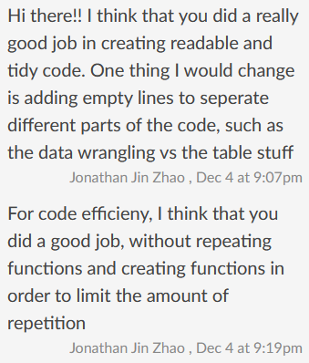

I think that during group work, I worked well with my group mates. I did try to follow the developer/coder roles, but it did tend to fall apart a little when we encounter challenges. I feel like a more flexible structure was good for solving problems, as each person could test out their ideas, without being hamstrung by communication problems or any other misunderstandings of what each group member wanted to use. I was not controlling and work well by communicating and being open to other ideas. I am always patient with my groupmates when we have conflicting ideas in approach to a problem , and we try each other’s potential solutions, rather than me overpowering them with my own ideas. I have learned to figure out problems and challenges with my various group mates during the PAs very well, and this was probably my favorite part of the course.